# Analiza i bazy danych

## Eksploracja danych

### dr hab. inż. Jerzy Baranowski, Prof. AGH

# Eksploracja danych

- bardziej sztuka niż nauka
- ogólny zestaw umiejętności a nie zamknięta procedura

# Oryginalny pomysł - Tukey

[figure not shown]

# Cele eksploracji danych

- Proponowanie nowych hipotez o obserwowanych w danych zależnościach
- Sprawdzanie zgodności danych z założeniami modeli statystycznych
- Wybranie adekwatnego do charakteru danych zestawu narzędzi i technik analizy

Tukey (źródło Wikipedia)

# Cele eksploracji danych

Podstawowym celem EDA jest maksymalizacja wglądu analityka w zestaw danych i w podstawową strukturę zbioru danych, przy jednoczesnym zapewnieniu wszystkich konkretnych elementów, które analityk chciałby wyodrębnić z zestawu danych, takich jak:

- dobrze dopasowany, oszczędny model
- lista wartości odstających
- poczucie solidności wniosków
- szacunki parametrów
- niepewności dotyczące tych szacunków
- uporządkowana lista ważnych czynników
- wnioski dotyczące tego, czy poszczególne czynniki są istotne statystycznie
- optymalne ustawienia

*NIST Engineering Statistics Handbook*

# Cele eksploracji danych

Analiza danych eksploracyjnych ma miejsce w „montażowni” projektu badawczego lub dowolnego badania opartego na danych. EDA to proces „wstępnego cięcia” do analizy danych, którego cel jest bardzo podobny do tego w sali montażowej filmu.

*R. Peng Exploratory data analysis*

# Cele eksploracji danych

EDA to cykl iteracyjny. W nim:

- Generuj pytania dotyczące swoich danych.
- Wyszukaj odpowiedzi, wizualizując, przekształcając i modelując swoje dane.
- Wykorzystaj zdobytą wiedzę, aby zawęzić swoje pytania i / lub wygenerować nowe pytania.

*G. Grolemund, H. Wickham - R for Data Analysis*

# Obsługa danych

Podstawą współczesnej analizy w Pythonie jest pakiet `pandas` (Python data analysis library).

https://pandas.pydata.org/

Za jego pomocą możemy w łatwy sposób obsługiwać dane tabelaryczne w formie obiektów typu `data frame`.

```python
import pandas as pd
tips=pd.read_csv('tips.csv')
tips.head()
```

|  | obs | totbill | tip | sex | smoker | day | time | size |
| --- | --- | --- | --- | --- | --- | --- | --- | --- |
| 0 | 1 | 16.99 | 1.01 | F | No | Sun | Night | 2 |
| 1 | 2 | 10.34 | 1.66 | M | No | Sun | Night | 3 |
| 2 | 3 | 21.01 | 3.50 | M | No | Sun | Night | 3 |
| 3 | 4 | 23.68 | 3.31 | M | No | Sun | Night | 2 |
| 4 | 5 | 24.59 | 3.61 | F | No | Sun | Night | 4 |

# Początki analizy

Na początek zawsze dobrze popatrzyc ile danych mamy i co to za dane.

```python
tips.info()
```

```
<class 'pandas.core.frame.DataFrame'>
RangeIndex: 244 entries, 0 to 243
Data columns (total 8 columns):
obs        244 non-null int64
totbill    244 non-null float64
tip        244 non-null float64
sex        244 non-null object
smoker     244 non-null object
day        244 non-null object
time       244 non-null object
size       244 non-null int64
dtypes: float64(2), int64(2), object(4)
memory usage: 15.4+ KB
```

# Wstępne statystyki

Dane numeryczne również można przeanalizować

```python
tips.describe()
```

|  | obs | totbill | tip | size |
| --- | --- | --- | --- | --- |
| count | 244.000000 | 244.000000 | 244.000000 | 244.000000 |
| mean | 122.500000 | 19.785943 | 2.998279 | 2.569672 |
| std | 70.580923 | 8.902412 | 1.383638 | 0.951100 |
| min | 1.000000 | 3.070000 | 1.000000 | 1.000000 |
| 25% | 61.750000 | 13.347500 | 2.000000 | 2.000000 |
| 50% | 122.500000 | 17.795000 | 2.900000 | 2.000000 |
| 75% | 183.250000 | 24.127500 | 3.562500 | 3.000000 |
| max | 244.000000 | 50.810000 | 10.000000 | 6.000000 |

Albo wszystkie

```python
tips.describe(include='all')
```

|  | obs | totbill | tip | sex | smoker | day | time | size |
| --- | --- | --- | --- | --- | --- | --- | --- | --- |
| count | 244.000000 | 244.000000 | 244.000000 | 244 | 244 | 244 | 244 | 244.000000 |
| unique | NaN | NaN | NaN | 2 | 2 | 4 | 2 | NaN |
| top | NaN | NaN | NaN | M | No | Sat | Night | NaN |
| freq | NaN | NaN | NaN | 157 | 151 | 87 | 176 | NaN |
| mean | 122.500000 | 19.785943 | 2.998279 | NaN | NaN | NaN | NaN | 2.569672 |
| std | 70.580923 | 8.902412 | 1.383638 | NaN | NaN | NaN | NaN | 0.951100 |
| min | 1.000000 | 3.070000 | 1.000000 | NaN | NaN | NaN | NaN | 1.000000 |
| 25% | 61.750000 | 13.347500 | 2.000000 | NaN | NaN | NaN | NaN | 2.000000 |
| 50% | 122.500000 | 17.795000 | 2.900000 | NaN | NaN | NaN | NaN | 2.000000 |
| 75% | 183.250000 | 24.127500 | 3.562500 | NaN | NaN | NaN | NaN | 3.000000 |
| max | 244.000000 | 50.810000 | 10.000000 | NaN | NaN | NaN | NaN | 6.000000 |

# Zastosowania pandas'a

`pandas` pozwala na szeroki zakres manipulacji z danymi, szczególnie użyteczne są:

- `melt` konwersja tabel z "szerokich" do "wysokich"
- `querry` filtrowanie po warunkach
- `assign` tworzenie nowych kolumn
- `loc` wybór kolumn
- `drop` usunięcie kolumn
- `agg` agregacja przez wybraną operację

```python
mtcars=pd.read_csv('mtcars.csv',delimiter=';',decimal=',')
```

```python
mtcars.info()
```

```
<class 'pandas.core.frame.DataFrame'>
RangeIndex: 32 entries, 0 to 31
Data columns (total 12 columns):
Unnamed: 0    32 non-null object
mpg           32 non-null float64
cyl           32 non-null int64
disp          32 non-null float64
hp            32 non-null int64
drat          32 non-null float64
wt            32 non-null float64
qsec          32 non-null float64
vs            32 non-null int64
am            32 non-null int64
gear          32 non-null int64
carb          32 non-null int64
dtypes: float64(5), int64(6), object(1)
memory usage: 3.1+ KB
```

```python
mtcars.describe(include='all')
```

|  | Unnamed: 0 | mpg | cyl | disp | hp | drat | wt | qsec | vs | am | gear | carb |
| --- | --- | --- | --- | --- | --- | --- | --- | --- | --- | --- | --- | --- |
| count | 32 | 32.000000 | 32.000000 | 32.000000 | 32.000000 | 32.000000 | 32.000000 | 32.000000 | 32.000000 | 32.000000 | 32.000000 | 32.0000 |
| unique | 32 | NaN | NaN | NaN | NaN | NaN | NaN | NaN | NaN | NaN | NaN | NaN |
| top | AMC Javelin | NaN | NaN | NaN | NaN | NaN | NaN | NaN | NaN | NaN | NaN | NaN |
| freq | 1 | NaN | NaN | NaN | NaN | NaN | NaN | NaN | NaN | NaN | NaN | NaN |
| mean | NaN | 20.090625 | 6.187500 | 230.721875 | 146.687500 | 3.596563 | 3.217250 | 17.848750 | 0.437500 | 0.406250 | 3.687500 | 2.8125 |
| std | NaN | 6.026948 | 1.785922 | 123.938694 | 68.562868 | 0.534679 | 0.978457 | 1.786943 | 0.504016 | 0.498991 | 0.737804 | 1.6152 |
| min | NaN | 10.400000 | 4.000000 | 71.100000 | 52.000000 | 2.760000 | 1.513000 | 14.500000 | 0.000000 | 0.000000 | 3.000000 | 1.0000 |
| 25% | NaN | 15.425000 | 4.000000 | 120.825000 | 96.500000 | 3.080000 | 2.581250 | 16.892500 | 0.000000 | 0.000000 | 3.000000 | 2.0000 |
| 50% | NaN | 19.200000 | 6.000000 | 196.300000 | 123.000000 | 3.695000 | 3.325000 | 17.710000 | 0.000000 | 0.000000 | 4.000000 | 2.0000 |
| 75% | NaN | 22.800000 | 8.000000 | 326.000000 | 180.000000 | 3.920000 | 3.610000 | 18.900000 | 1.000000 | 1.000000 | 4.000000 | 4.0000 |
| max | NaN | 33.900000 | 8.000000 | 472.000000 | 335.000000 | 4.930000 | 5.424000 | 22.900000 | 1.000000 | 1.000000 | 5.000000 | 8.0000 |

```python
mtcars=mtcars.rename(columns={'Unnamed: 0':'model'})
mtcars.query("~((am == 1) & (hp / cyl >= 20))").head()
```

|  | model | mpg | cyl | disp | hp | drat | wt | qsec | vs | am | gear | carb |
| --- | --- | --- | --- | --- | --- | --- | --- | --- | --- | --- | --- | --- |
| 0 | Mazda RX4 | 21.0 | 6 | 160.0 | 110 | 3.90 | 2.620 | 16.46 | 0 | 1 | 4 | 4 |
| 1 | Mazda RX4 Wag | 21.0 | 6 | 160.0 | 110 | 3.90 | 2.875 | 17.02 | 0 | 1 | 4 | 4 |
| 3 | Hornet 4 Drive | 21.4 | 6 | 258.0 | 110 | 3.08 | 3.215 | 19.44 | 1 | 0 | 3 | 1 |
| 4 | Hornet Sportabout | 18.7 | 8 | 360.0 | 175 | 3.15 | 3.440 | 17.02 | 0 | 0 | 3 | 2 |
| 5 | Valiant | 18.1 | 6 | 225.0 | 105 | 2.76 | 3.460 | 20.22 | 1 | 0 | 3 | 1 |

```python
mtcars.loc[:, ["mpg", "cyl", "disp", "hp", "drat", "wt", "qsec"]].head()
```

|  | mpg | cyl | disp | hp | drat | wt | qsec |
| --- | --- | --- | --- | --- | --- | --- | --- |
| 0 | 21.0 | 6 | 160.0 | 110 | 3.90 | 2.620 | 16.46 |
| 1 | 21.0 | 6 | 160.0 | 110 | 3.90 | 2.875 | 17.02 |
| 2 | 22.8 | 4 | 108.0 | 93 | 3.85 | 2.320 | 18.61 |
| 3 | 21.4 | 6 | 258.0 | 110 | 3.08 | 3.215 | 19.44 |
| 4 | 18.7 | 8 | 360.0 | 175 | 3.15 | 3.440 | 17.02 |

```python
import numpy as np
mtcars.agg({"mpg": [np.mean, np.max], "hp": [np.min]})
```

|  | mpg | hp |
| --- | --- | --- |
| amax | 33.900000 | NaN |
| amin | NaN | 52.0 |
| mean | 20.090625 | NaN |

```python
mtcars.assign(mean_mpg_by_am = lambda x: x.loc[:,["am", "mpg"]].groupby(["am"]).transform(np.mean)).head()
```

|  | model | mpg | cyl | disp | hp | drat | wt | qsec | vs | am | gear | carb | mean_mpg_by_am |
| --- | --- | --- | --- | --- | --- | --- | --- | --- | --- | --- | --- | --- | --- |
| 0 | Mazda RX4 | 21.0 | 6 | 160.0 | 110 | 3.90 | 2.620 | 16.46 | 0 | 1 | 4 | 4 | 24.392308 |
| 1 | Mazda RX4 Wag | 21.0 | 6 | 160.0 | 110 | 3.90 | 2.875 | 17.02 | 0 | 1 | 4 | 4 | 24.392308 |
| 2 | Datsun 710 | 22.8 | 4 | 108.0 | 93 | 3.85 | 2.320 | 18.61 | 1 | 1 | 4 | 1 | 24.392308 |
| 3 | Hornet 4 Drive | 21.4 | 6 | 258.0 | 110 | 3.08 | 3.215 | 19.44 | 1 | 0 | 3 | 1 | 17.147368 |
| 4 | Hornet Sportabout | 18.7 | 8 | 360.0 | 175 | 3.15 | 3.440 | 17.02 | 0 | 0 | 3 | 2 | 17.147368 |

```python
def transform1(x):
    return max(x)-min(x)
def transform2(x):
    return max(x)+5
py_mt = (mtcars
            .loc[:,["cyl", "model", "hp", "drat"]] #select
            .query("cyl > 4") #filter
            .groupby("cyl") #group_by
            .agg({ #summarise, agg is an abbreviation of aggregation
                    'hp':'mean',
                    'drat':[
                        'mean',
                        'std',
                        transform1,
                        transform2]
            })
            .sort_values(by=[("drat", "mean")])
            # multindex sort (unique to pandas)
        )
```

```python
py_mt
```

| cyl | hp mean | drat mean | drat std | drat transform1 | drat transform2 |
| --- | --- | --- | --- | --- | --- |
| 8 | 209.214286 | 3.229286 | 0.372362 | 1.46 | 9.22 |
| 6 | 122.285714 | 3.585714 | 0.476055 | 1.16 | 8.92 |

Pandas umożliwa również w ograniczyonym zakresie wizualizację.

```python
import matplotlib.pyplot as plt

tips.plot.scatter(x='totbill',y='tip',marker='o')
```

[output not shown]

**Wykres punktowy** - ang. *scatterplot* jest najpopularniejszym wykresem w analizie danych.

Pandas ma ograniczone możliwości wizualizacyjne. Generalnie matplotlib pozwala na więcej:

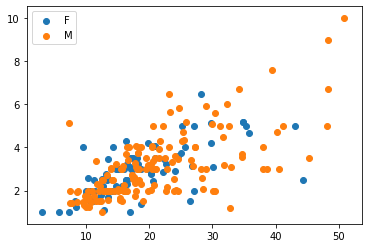

```python
fig, ax = plt.subplots()
for c, df_ in tips.groupby('sex'):
    ax.scatter(df_['totbill'], df_['tip'], label=c)
ax.legend()
```

# Pakiety wizualizacjne

Zasadniczo wizualizację umożliwia wiele pakietów, które są dużo łatwiejsze w użyciu.

# Seaborn

[figure not shown]

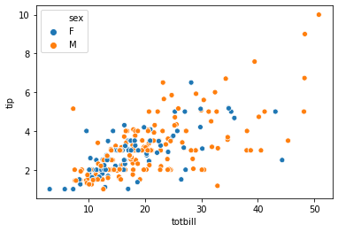

```python
import seaborn as sns
ax = sns.scatterplot(x="totbill", y="tip", hue="sex",data=tips)
```

Popularny, miesza trochę w `matplotlib`'ie.

# Plotnine

[figure not shown]

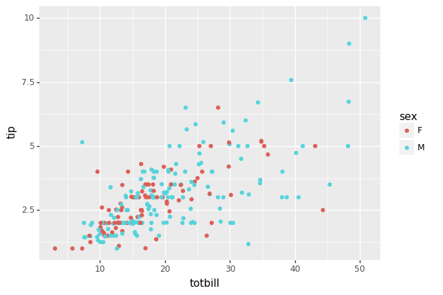

```python
import plotnine as p9
p=p9.ggplot(p9.aes(x='totbill', y='tip'),data=tips)
p+p9.geom_point(p9.aes(color='sex'))
```

Wzorowany na `ggplot2` z R. Wymaga przyzwyczajenia się do grammar of graphics.

# Plotly

[figure not shown]

```python
import plotly.express as px
fig = px.scatter(tips, x="totbill", y="tip", color="sex",height=400)
fig.show()
```

[interactive chart not shown]

Chwilowo najbardziej technicznie rozwinięty. Dobry do grafiki webowej. Działa na iPadzie. Na wykładzie będziemy używać `plotly.express` - modułu do prototypowania analizy.

# Long data

Dane w postaci tidy, są zawsze long. Postać long pozwala na wykorzystanie wszystkich możliwości pakietów wizualizacyjnych.

```python
wide_df = pd.DataFrame(dict(Month=["Jan", "Feb", "Mar"], London=[1,2,3], Paris=[3,1,2]))
wide_df
```

|  | Month | London | Paris |
| --- | --- | --- | --- |
| 0 | Jan | 1 | 3 |
| 1 | Feb | 2 | 1 |
| 2 | Mar | 3 | 2 |

```python
tidy_df = wide_df.melt(id_vars="Month")
tidy_df
```

|  | Month | variable | value |
| --- | --- | --- | --- |
| 0 | Jan | London | 1 |
| 1 | Feb | London | 2 |
| 2 | Mar | London | 3 |
| 3 | Jan | Paris | 3 |
| 4 | Feb | Paris | 1 |
| 5 | Mar | Paris | 2 |

Wykres słupkowy (bar graph)

```python
fig = px.bar(tidy_df, x="Month", y="value", color="variable",
             barmode="group"
             #barmode='overlay'
             #barmode='relative'
            )
```

```python
fig.show()
```

[interactive chart not shown]

Histogram

```python
fig_tip_hist=px.histogram(tips,
                          x='tip'
                          ,marginal='rug'
                         )
```

```python
fig_tip_hist.show()
```

[interactive chart not shown]

Wykres skrzynkowy (*box plot*)

```python
fig_tip_box=px.box(tips,
                   x="tip",
                   points='all',
                   orientation='h')
```

```python
fig_tip_box.show()
```

[interactive chart not shown]

# Case studies

# Napiwki

Zebrane dane z grupy wizyt w restauracji.

Brak eksploracji tylko zastosowanie uczenia maszynowego zaowocował prostym modelem regresyjnym wiążącym liczebność grupy z procentową wysokością napiwku.

Przyjrzyjmy się danym dokładniej.

```python
fig_tip_hist=px.histogram(tips, x='tip',nbins=100)
fig_tip_hist.show()
```

[interactive chart not shown]

Ludzie zaokrąglają napiwki - czy nie należy tego uwzględnić w analizie?

```python
fig = px.scatter(tips, x="totbill", y="tip", facet_row="sex", facet_col="smoker", color="time")
fig.show()
```

[interactive chart not shown]

# Pasażerowie Titanica

Zestaw danych z Kaggle'a

```python
titanic=pd.read_csv('train.csv')
titanic.head()
```

|  | PassengerId | Survived | Pclass | Name | Sex | Age | SibSp | Parch | Ticket | Fare | Cabin | Embarked |
| --- | --- | --- | --- | --- | --- | --- | --- | --- | --- | --- | --- | --- |
| 0 | 1 | 0 | 3 | Braund, Mr. Owen Harris | male | 22.0 | 1 | 0 | A/5 21171 | 7.2500 | NaN | S |
| 1 | 2 | 1 | 1 | Cumings, Mrs. John Bradley (Florence Briggs Th... | female | 38.0 | 1 | 0 | PC 17599 | 71.2833 | C85 | C |
| 2 | 3 | 1 | 3 | Heikkinen, Miss. Laina | female | 26.0 | 0 | 0 | STON/O2. 3101282 | 7.9250 | NaN | S |
| 3 | 4 | 1 | 1 | Futrelle, Mrs. Jacques Heath (Lily May Peel) | female | 35.0 | 1 | 0 | 113803 | 53.1000 | C123 | S |
| 4 | 5 | 0 | 3 | Allen, Mr. William Henry | male | 35.0 | 0 | 0 | 373450 | 8.0500 | NaN | S |

```python
titanic.describe()
```

|  | PassengerId | Survived | Pclass | Age | SibSp | Parch | Fare |
| --- | --- | --- | --- | --- | --- | --- | --- |
| count | 891.000000 | 891.000000 | 891.000000 | 714.000000 | 891.000000 | 891.000000 | 891.000000 |
| mean | 446.000000 | 0.383838 | 2.308642 | 29.699118 | 0.523008 | 0.381594 | 32.204208 |
| std | 257.353842 | 0.486592 | 0.836071 | 14.526497 | 1.102743 | 0.806057 | 49.693429 |
| min | 1.000000 | 0.000000 | 1.000000 | 0.420000 | 0.000000 | 0.000000 | 0.000000 |
| 25% | 223.500000 | 0.000000 | 2.000000 | 20.125000 | 0.000000 | 0.000000 | 7.910400 |
| 50% | 446.000000 | 0.000000 | 3.000000 | 28.000000 | 0.000000 | 0.000000 | 14.454200 |
| 75% | 668.500000 | 1.000000 | 3.000000 | 38.000000 | 1.000000 | 0.000000 | 31.000000 |
| max | 891.000000 | 1.000000 | 3.000000 | 80.000000 | 8.000000 | 6.000000 | 512.329200 |

```python
titanic.dropna().describe()
```

|  | PassengerId | Survived | Pclass | Age | SibSp | Parch | Fare |
| --- | --- | --- | --- | --- | --- | --- | --- |
| count | 183.000000 | 183.000000 | 183.000000 | 183.000000 | 183.000000 | 183.000000 | 183.000000 |
| mean | 455.366120 | 0.672131 | 1.191257 | 35.674426 | 0.464481 | 0.475410 | 78.682469 |
| std | 247.052476 | 0.470725 | 0.515187 | 15.643866 | 0.644159 | 0.754617 | 76.347843 |
| min | 2.000000 | 0.000000 | 1.000000 | 0.920000 | 0.000000 | 0.000000 | 0.000000 |
| 25% | 263.500000 | 0.000000 | 1.000000 | 24.000000 | 0.000000 | 0.000000 | 29.700000 |
| 50% | 457.000000 | 1.000000 | 1.000000 | 36.000000 | 0.000000 | 0.000000 | 57.000000 |
| 75% | 676.000000 | 1.000000 | 1.000000 | 47.500000 | 1.000000 | 1.000000 | 90.000000 |
| max | 890.000000 | 1.000000 | 3.000000 | 80.000000 | 3.000000 | 4.000000 | 512.329200 |

```python
titanic.dropna(subset=['Age']).describe()
```

|  | PassengerId | Survived | Pclass | Age | SibSp | Parch | Fare |
| --- | --- | --- | --- | --- | --- | --- | --- |
| count | 714.000000 | 714.000000 | 714.000000 | 714.000000 | 714.000000 | 714.000000 | 714.000000 |
| mean | 448.582633 | 0.406162 | 2.236695 | 29.699118 | 0.512605 | 0.431373 | 34.694514 |
| std | 259.119524 | 0.491460 | 0.838250 | 14.526497 | 0.929783 | 0.853289 | 52.918930 |
| min | 1.000000 | 0.000000 | 1.000000 | 0.420000 | 0.000000 | 0.000000 | 0.000000 |
| 25% | 222.250000 | 0.000000 | 1.000000 | 20.125000 | 0.000000 | 0.000000 | 8.050000 |
| 50% | 445.000000 | 0.000000 | 2.000000 | 28.000000 | 0.000000 | 0.000000 | 15.741700 |
| 75% | 677.750000 | 1.000000 | 3.000000 | 38.000000 | 1.000000 | 1.000000 | 33.375000 |
| max | 891.000000 | 1.000000 | 3.000000 | 80.000000 | 5.000000 | 6.000000 | 512.329200 |

```python
titanic.info()
```

```
<class 'pandas.core.frame.DataFrame'>
RangeIndex: 891 entries, 0 to 890
Data columns (total 12 columns):
PassengerId    891 non-null int64
Survived       891 non-null int64
Pclass         891 non-null int64
Name           891 non-null object
Sex            891 non-null object
Age            714 non-null float64
SibSp          891 non-null int64
Parch          891 non-null int64
Ticket         891 non-null object
Fare           891 non-null float64
Cabin          204 non-null object
Embarked       889 non-null object
dtypes: float64(2), int64(5), object(5)
memory usage: 83.7+ KB
```

# Brakujące dane

Brakuje dużo danych, w szczególności numeru kabiny i wieku. Co zrobić?

```python
ans_df=pd.read_csv('ANSCOMBE.csv')
ans_df.describe()
```

|  | X1 | Y1 | X2 | Y2 | X3 | Y3 | X4 | Y4 |
| --- | --- | --- | --- | --- | --- | --- | --- | --- |
| count | 11.000000 | 11.000000 | 11.000000 | 11.000000 | 11.000000 | 11.000000 | 11.000000 | 11.000000 |
| mean | 9.000000 | 7.500909 | 9.000000 | 7.500909 | 9.000000 | 7.500000 | 9.000000 | 7.500909 |
| std | 3.316625 | 2.031568 | 3.316625 | 2.031657 | 3.316625 | 2.030424 | 3.316625 | 2.030579 |
| min | 4.000000 | 4.260000 | 4.000000 | 3.100000 | 4.000000 | 5.390000 | 8.000000 | 5.250000 |
| 25% | 6.500000 | 6.315000 | 6.500000 | 6.695000 | 6.500000 | 6.250000 | 8.000000 | 6.170000 |
| 50% | 9.000000 | 7.580000 | 9.000000 | 8.140000 | 9.000000 | 7.110000 | 8.000000 | 7.040000 |
| 75% | 11.500000 | 8.570000 | 11.500000 | 8.950000 | 11.500000 | 7.980000 | 8.000000 | 8.190000 |
| max | 14.000000 | 10.840000 | 14.000000 | 9.260000 | 14.000000 | 12.740000 | 19.000000 | 12.500000 |

```python
ans_df['id']=ans_df.index
tidy_ans_df=pd.wide_to_long(ans_df,['X','Y'],i='id',j='set').reset_index().drop(columns='id')
tidy_ans_df['set']=tidy_ans_df['set'].astype('category')
```

```python
fig_ans = px.scatter(tidy_ans_df,
                     x="X",
                     y="Y",
                     color='set',
                     marginal_x='box',
                     trendline='ols'
                    )
```

```python
fig_ans.show()
```

[interactive chart not shown]

Całkowicie różne dane mają dokładnie ten sam model regresyjny.